# Stage 3 rectal cancer adjuvant management: survival analysis

# 1 Patient baseline profiles

```
## Setting theme `JAMA`
```

```
## 5 observations missing `adjuvant_management` have been removed. To include these observations, use `forcats::fct_explicit_na()` on `adjuvant_management` column before passing to `tbl_summary()`.
```

| **Characteristic** | **N** | **adjuvant_chemo**, N = 101 | **surveillence**, N = 75 | **p-value**<sup>1</sup> |
| --- | --- | --- | --- | --- |
| Age at diagnosis, Median (IQR) | 175 | 63 (55 – 70) | 70 (62 – 78) | <0.001 |
| CRM, n (%) | 148 |  |  | 0.007 |
| pos |  | 74 (88) | 45 (70) |  |
| neg |  | 10 (12) | 19 (30) |  |
| R status, n (%) | 167 |  |  | 0.064 |
| R0 |  | 78 (84) | 70 (95) |  |
| R1 |  | 13 (14) | 4 (5.4) |  |
| R2 |  | 2 (2.2) | 0 (0) |  |
| TRG status, n (%) | 80 |  |  | 0.90 |
| TRG3 |  | 12 (26) | 11 (32) |  |
| TRG0 |  | 0 (0) | 1 (2.9) |  |
| TRG1 |  | 5 (11) | 3 (8.8) |  |
| TRG2 |  | 25 (54) | 16 (47) |  |
| TRG4 |  | 2 (4.3) | 2 (5.9) |  |
| TRG5 |  | 2 (4.3) | 1 (2.9) |  |
| Distance from anal verge, Median (IQR) | 151 | 3.00 (1.00 – 6.00) | 4.00 (2.00 – 6.00) | 0.19 |
| EMVI, n (%) | 121 |  |  | <0.001 |
| neg |  | 19 (28) | 31 (60) |  |
| pos |  | 50 (72) | 21 (40) |  |
| Time between radiotherapy and surgery, Median (IQR) | 173 | 87 (77 – 100) | 89 (77 – 118) | 0.26 |
| Baseline histological grade, n (%) | 166 |  |  | 0.90 |
| G3 |  | 12 (13) | 10 (14) |  |
| G1 |  | 1 (1.1) | 0 (0) |  |
| G2 |  | 82 (86) | 61 (86) |  |
| Cancer staging post surgery, n (%) | 172 |  |  | <0.001 |
| stage_3 |  | 32 (32) | 9 (12) |  |
| stage_0 |  | 8 (8.1) | 11 (15) |  |
| stage_1 |  | 15 (15) | 35 (48) |  |
| stage_2 |  | 44 (44) | 18 (25) |  |
| Cancer staging post radiotherapy, n (%) | 136 |  |  | 0.011 |
| stage_3 |  | 34 (44) | 18 (31) |  |
| stage_0 |  | 2 (2.6) | 2 (3.4) |  |
| stage_1 |  | 8 (10) | 19 (33) |  |
| stage_2 |  | 33 (42) | 19 (33) |  |
| stage_4 |  | 1 (1.3) | 0 (0) |  |

<sup>*1*</sup> Wilcoxon rank sum test; Pearson's Chi-squared test; Fisher's exact test

# 2 Missing data pattern

> TRG status, EMVI and cancer stage post radiotherapy are observed to display more than 20% missingness. These co-variates are excluded from subsequent multivariate analysis.

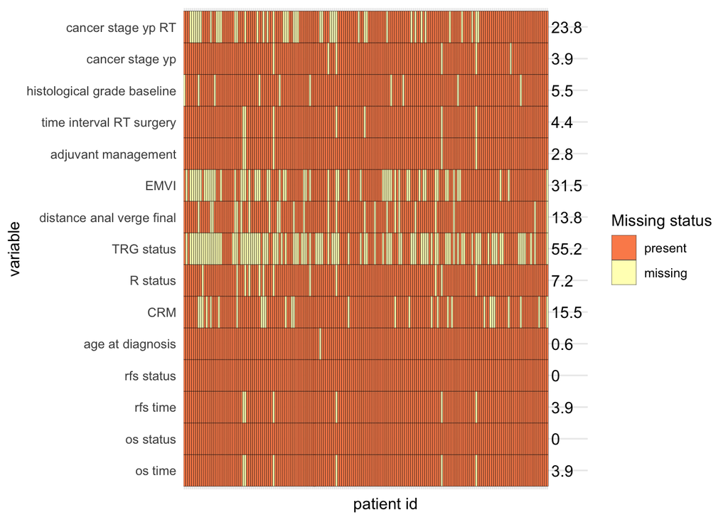

# 3 Survival analysis

## 3.1 KM curve and log-rank test

> No significant difference in overall survival was detected between the KM curve of two groups using log-rank test (p=0.58)

### 3.1.1 Overall survival

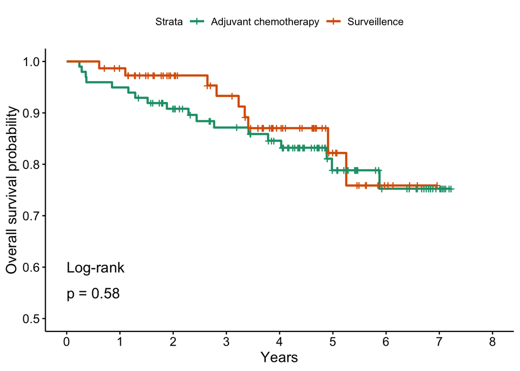

### 3.1.2 Recurrence-free survival

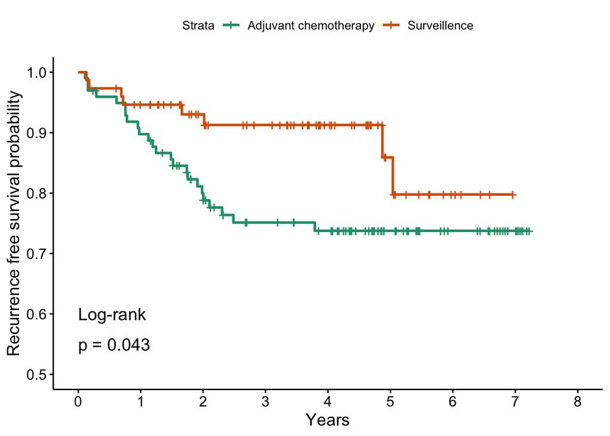

## 3.2 Univariate cox regression

> Univariate cox regression was conducted to check each included variables influence on final survival outcome

### 3.2.2 Recurrence free survival

**Recurrence free survival univariate**

| **Characteristic** | **N** | **HR** **(95% CI)**<sup>1</sup> | **p-value** |
| --- | --- | --- | --- |
| Age at diagnosis | 173 | 0.98 (0.95 to 1.01) | 0.17 |
| CRM | 146 |  |  |
| pos |  | — |  |
| neg |  | 0.41 (0.12 to 1.35) | 0.14 |
| R status | 167 |  |  |
| R0 |  | — |  |
| R1 |  | 7.30 (3.33 to 16.0) | <0.001 |
| R2 |  | 0.00 (0.00 to Inf) | >0.99 |
| TRG status | 80 |  |  |
| TRG3 |  | — |  |
| TRG0 |  | 0.00 (0.00 to Inf) | >0.99 |
| TRG1 |  | 5.13 (1.15 to 23.0) | 0.033 |
| TRG2 |  | 1.36 (0.35 to 5.27) | 0.66 |
| TRG4 |  | 0.00 (0.00 to Inf) | >0.99 |
| TRG5 |  | 0.00 (0.00 to Inf) | >0.99 |
| Distance from anal verge | 151 | 1.09 (0.95 to 1.25) | 0.21 |
| EMVI | 120 |  |  |
| neg |  | — |  |
| pos |  | 1.50 (0.57 to 3.95) | 0.41 |
| adjuvant_management | 174 |  |  |
| adjuvant_chemo |  | — |  |
| surveillence |  | 0.45 (0.20 to 1.00) | 0.049 |
| Time between radiotherapy and surgery | 173 | 1.00 (1.00 to 1.00) | 0.98 |
| Baseline histological grade | 164 |  |  |
| G3 |  | — |  |
| G1 |  | 0.00 (0.00 to Inf) | >0.99 |
| G2 |  | 0.55 (0.22 to 1.36) | 0.19 |
| Cancer staging post surgery | 172 |  |  |
| stage_3 |  | — |  |
| stage_0 |  | 0.20 (0.03 to 1.59) | 0.13 |
| stage_1 |  | 0.56 (0.21 to 1.47) | 0.24 |
| stage_2 |  | 1.00 (0.44 to 2.25) | >0.99 |
| Cancer staging post radiotherapy | 136 |  |  |
| stage_3 |  | — |  |
| stage_0 |  | 1.10 (0.14 to 8.44) | 0.93 |
| stage_1 |  | 0.83 (0.29 to 2.37) | 0.73 |
| stage_2 |  | 0.60 (0.24 to 1.53) | 0.29 |
| stage_4 |  | 0.00 (0.00 to Inf) | >0.99 |

<sup>*1*</sup> HR = Hazard Ratio, CI = Confidence Interval

## 3.3 Firth penalised multivariate cox regression

> Next we aimed to compare the OS and RFS between adjuvant chemo and surveillance group using multivariate logistical regression accounting for known clinical prognostic factors. Firth penalised cox regression was used as some variables contained groups with relatively small number of samples.A maximum iteration of 500 and maximum step per iteration of 0.5 was used.